# Client Satisfaction Report

Part 3 of 3: Analysis of Customer Sat Comments

August 2019 (Surveys 1-4)

### Overview

This report analyzes the occurrences of positive and negative vocabulary words in the comments field of the TSG customer satisfaction surveys. The statistics are for four surveys, taken as follows:

- Fall 2018
- Winter 2019
- Spring 2019
- Summer 2019

Note that each survey was distributed to a unique 25% of the organization, and therefore does not follow the principle of “random selection with replacement.” However, the surveys provide a working sense of the organization’s opinions.

Words used by responders can provide some useful insight into how responders are thinking and what troubles (or delights) them most. Totaling the number of occurrences of positives and negatives and looking at various ratos can provide some sense of how happy responders are (and with what).

Positive, negative, and neutral vocabularly words were selected by reading through the comments manually, examining the context, and selecting those that would, in as many cases as possible, be unambiguous. The code reads each comment, and tabulates the number of occurrences of each word or phrase on the list - cumulatively, and by individual survey.

### Summary

Through the four surveys taken to date, the following trends appear to be true:

Overall, the opinion of TSG is positive but with ample opportunity for improvement. Three areas appear to be important to responders, and where TSG should strive to excel:

- Job knowledge (the person knows what they are doing)
- Speed (my problem is resolved quickly and the first time)
- Empathy (the person is easy to deal with and understands my problem)

### Other Notes and Recommendations

A few recommendations surfaced within the comments that may be worth while for the management team to consider:

- Please collect the “best practices” and new software ideas from all employees and share them with others to improve everyone’s productivity.
- I think TSG would benefit by having more interns who can support innovation and research. The vendor management internship is a good example of how this can be a winning experience for everyone involved.
- For an existing employee who is transitioning to a new role… Before you require them to get a new email account (as I was required to do), you should explain to them why it is necessary.

A full list of the comments can be found in column N of the responses spreadsheet. This can be accessed here: https://docs.google.com/spreadsheets/d/1tzD84pHfpDht0IESMPmWr-wjkoEiSbLvFo5Z5uU6A-Y/edit#gid=1724531182. These are worth looking at.

### Cumulative View

This section looks at the cumulative picture and summarizes the statistics and vocabularly occurrences (positive and negative) across all surveys to date.

The Top 10 Postive and Negative words are shown below. See the Appendix for a complete list of word occurrences and counts.

```
            Word Count Type
1           help    30  Pos
2          great    10  Pos
3     responsive     7  Pos
4   professional     6  Pos
5     appreciate     5  Pos
6        patient     5  Pos
7         timely     5  Pos
8       friendly     4  Pos
9           easy     3  Pos
10 knowledgeable     3  Pos
```

```
            Word Count Type
1     Enterprise     5  Neg
2       problems     4  Neg
3      challenge     3  Neg
4         issues     3  Neg
5         didn't     2  Neg
6        doesn't     2  Neg
7     negatively     2  Neg
8    really need     2  Neg
9           slow     2  Neg
10 unnecessarily     2  Neg
```

```
                          Word Count Type
1                      resolve     4  Neu
2              a good example      1  Neu
3          answer can be found     1  Neu
4                appropriately     1  Neu
5  can be a winning experience     1  Neu
6             can be addressed     1  Neu
7           conduct themselves     1  Neu
8                could help me     1  Neu
9                   customized     1  Neu
10                    feedback     1  Neu
```

```
 Number of survey responses      : 190
 Number of survey comments       : 68
 Comments to responses ratio     : 0.3578947

 Number of positive words        : 156
 Positive words to comments ratio: 2.294118

 Number of negative words        : 82
 Negative words to comments ratio: 1.205882

 Number of neutral words         : 31
 Neutral words to comments raito : 0.4558824
```

A second appendix includes a word cloud version of the entire comments set.

### Individual Survey View

This section looks at the positive and negative vocabularly tabulations by individual surveys. Explanations of the various statistics are given below.

```
Results for 01-F18
Number of responses             : 37
Number of comments              : 11
Comments to responses ratio     : 0.3
Number of positive words        : 22
Positive words to comments ratio: 2
Number of negative words        : 29
Negative words to comments ratio: 2.64
Number of neutral words         : 9
Neutral words to comments ratio : 0.82

Results for 02-W19
Number of responses             : 35
Number of comments              : 17
Comments to responses ratio     : 0.49
Number of positive words        : 41
Positive words to comments ratio: 2.41
Number of negative words        : 27
Negative words to comments ratio: 1.59
Number of neutral words         : 13
Neutral words to comments ratio : 0.76

Results for 03-S19
Number of responses             : 61
Number of comments              : 21
Comments to responses ratio     : 0.34
Number of positive words        : 54
Positive words to comments ratio: 2.57
Number of negative words        : 21
Negative words to comments ratio: 1
Number of neutral words         : 2
Neutral words to comments ratio : 0.1

Results for 04-S19
Number of responses             : 57
Number of comments              : 19
Comments to responses ratio     : 0.33
Number of positive words        : 39
Positive words to comments ratio: 2.05
Number of negative words        : 5
Negative words to comments ratio: 0.26
Number of neutral words         : 7
Neutral words to comments ratio : 0.37
```

**Overall Summary of Individual Survey Statistics**

Translation of field names:

- Resp = number of responses
- Comms = the number of comments in the survey
- c_to_r_ratio = the number of comments divided by the number of responses
- PosWds = the number of positive words found in the survey
- pw_to_c_ratio = the number of positive words divided by the number of comments
- NegWds = the number of negative words found in the survey
- nw_to_c_ratio = the number of negative words divided by the number of comments
- NueWds = the number of neutral words found in the survey
- neu_to_c_ratio = the number of neutral words divided by the number of comments

| Survey | Resp | Comms | c_to_r_ratio | PosWds | pw_to_c_ratio | NegWds | nw_to_c_ratio | NeuWds | neu_to_c_ratio |
| --- | --- | --- | --- | --- | --- | --- | --- | --- | --- |
| 01-F18 | 37 | 11 | 0.30 | 22 | 2.00 | 29 | 2.64 | 9 | 0.82 |
| 02-W19 | 35 | 17 | 0.49 | 41 | 2.41 | 27 | 1.59 | 13 | 0.76 |
| 03-S19 | 61 | 21 | 0.34 | 54 | 2.57 | 21 | 1.00 | 2 | 0.10 |
| 04-S19 | 57 | 19 | 0.33 | 39 | 2.05 | 5 | 0.26 | 7 | 0.37 |

Graphical representations of the summary statistics by Survey are shown below.

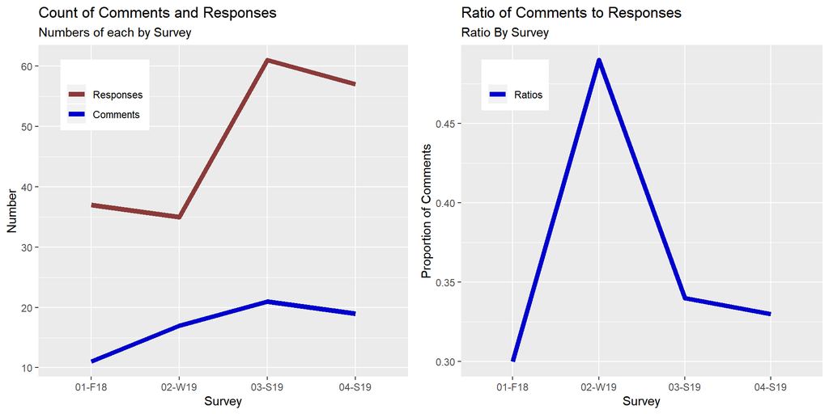

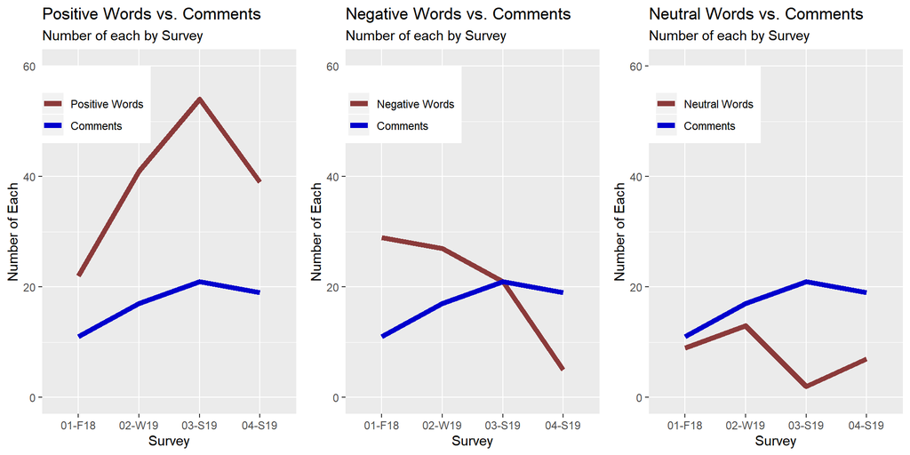

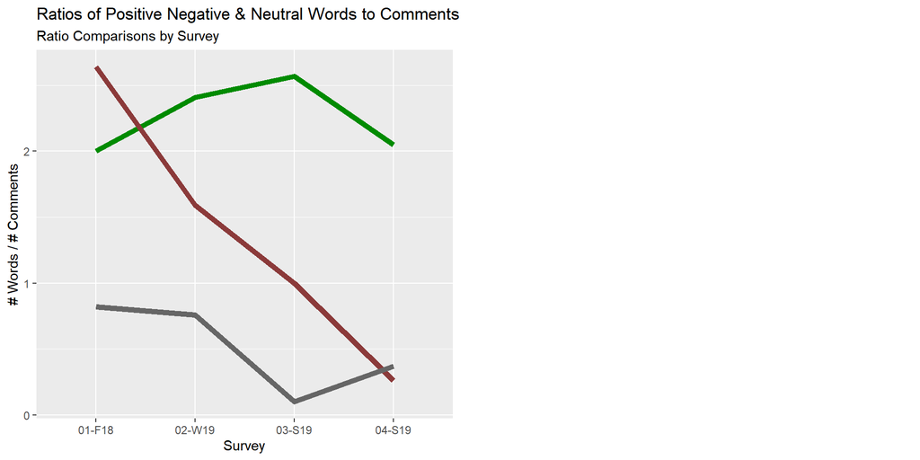

### Appendix - Summary of Positive Vocabularly Words

**Positive Vocabulary word counts / occurrences**

| Word | Count | Type |
| --- | --- | --- |
| help | 30 | Pos |
| great | 10 | Pos |
| responsive | 7 | Pos |
| professional | 6 | Pos |
| appreciate | 5 | Pos |
| patient | 5 | Pos |
| timely | 5 | Pos |
| friendly | 4 | Pos |
| easy | 3 | Pos |
| knowledgeable | 3 | Pos |
| prompt | 3 | Pos |
| very helpful | 3 | Pos |
| willing | 3 | Pos |
| always patient | 2 | Pos |
| appreciated | 2 | Pos |
| courteous | 2 | Pos |
| devoted | 2 | Pos |
| effective | 2 | Pos |
| excellent | 2 | Pos |
| gracious | 2 | Pos |
| highlight | 2 | Pos |
| kind | 2 | Pos |
| love | 2 | Pos |
| love working with | 2 | Pos |
| outstanding | 2 | Pos |
| pleasant | 2 | Pos |
| skilled | 2 | Pos |
| very good | 2 | Pos |
| above and beyond | 1 | Pos |
| always ready | 1 | Pos |
| awesome | 1 | Pos |
| capable | 1 | Pos |
| cheerfully | 1 | Pos |
| competent | 1 | Pos |
| couldn’t do my job without | 1 | Pos |
| easy to follow | 1 | Pos |
| empathetic | 1 | Pos |
| excellent attitude | 1 | Pos |
| exceptional | 1 | Pos |
| extra mile | 1 | Pos |
| fantastic | 1 | Pos |
| favorite people | 1 | Pos |
| follow-through | 1 | Pos |
| fun to work with | 1 | Pos |
| generous | 1 | Pos |
| goes out of their way | 1 | Pos |
| graciously | 1 | Pos |
| hard work | 1 | Pos |
| joy to work with | 1 | Pos |
| joyful | 1 | Pos |
| loving | 1 | Pos |
| perseverance | 1 | Pos |
| pleasure | 1 | Pos |
| quick to respond | 1 | Pos |
| quicker | 1 | Pos |
| satisfied | 1 | Pos |
| shining star | 1 | Pos |
| solution-oriented | 1 | Pos |
| speed | 1 | Pos |
| super | 1 | Pos |
| super competent | 1 | Pos |
| supporting the Cause | 1 | Pos |
| thanks | 1 | Pos |
| they find out | 1 | Pos |
| thorough | 1 | Pos |
| upbeat | 1 | Pos |
| warm | 1 | Pos |

### Appendix - Summary of Negative Vocabularly Words

**Negative Vocabulary word counts / occurrences**

| Word | Count | Type |
| --- | --- | --- |
| Enterprise | 5 | Neg |
| problems | 4 | Neg |
| challenge | 3 | Neg |
| issues | 3 | Neg |
| didn’t | 2 | Neg |
| doesn’t | 2 | Neg |
| negatively | 2 | Neg |
| really need | 2 | Neg |
| slow | 2 | Neg |
| unnecessarily | 2 | Neg |
| addressing the issue | 1 | Neg |
| again and again | 1 | Neg |
| appears | 1 | Neg |
| back and forth | 1 | Neg |
| bandwidth | 1 | Neg |
| could conduct | 1 | Neg |
| could have gotten | 1 | Neg |
| create excessive | 1 | Neg |
| devote a bit more time | 1 | Neg |
| did not know what they were doing | 1 | Neg |
| difficulty | 1 | Neg |
| disconnect | 1 | Neg |
| docked | 1 | Neg |
| ended up | 1 | Neg |
| endure | 1 | Neg |
| excessively | 1 | Neg |
| glitchy | 1 | Neg |
| hard time | 1 | Neg |
| haven’t been able to | 1 | Neg |
| having more | 1 | Neg |
| impacted | 1 | Neg |
| implications | 1 | Neg |
| inconvenienced | 1 | Neg |
| inexperience | 1 | Neg |
| inferior | 1 | Neg |
| keep you on hold | 1 | Neg |
| left straddling | 1 | Neg |
| little vague | 1 | Neg |
| many days | 1 | Neg |
| more palatable | 1 | Neg |
| need to get better | 1 | Neg |
| needs some work | 1 | Neg |
| never know | 1 | Neg |
| never to call | 1 | Neg |
| no clear plan | 1 | Neg |
| not consistently | 1 | Neg |
| not yet | 1 | Neg |
| on hold | 1 | Neg |
| problematic | 1 | Neg |
| putting off projects | 1 | Neg |
| should not raise | 1 | Neg |
| should strive | 1 | Neg |
| take too long | 1 | Neg |
| taken months | 1 | Neg |
| takes many days | 1 | Neg |
| takes more time | 1 | Neg |
| too busy | 1 | Neg |
| unhelpful | 1 | Neg |
| unresolved | 1 | Neg |
| upheaval | 1 | Neg |
| vague | 1 | Neg |
| well-intentioned | 1 | Neg |
| what was going on | 1 | Neg |
| would have been nice | 1 | Neg |
| would not quite say | 1 | Neg |

### Appendix - Summary of Neutral Vocabularly Words

**Neutral Vocabulary word counts / occurrences**

| Word | Count | Type |
| --- | --- | --- |
| resolve | 4 | Neu |
| a good example | 1 | Neu |
| answer can be found | 1 | Neu |
| appropriately | 1 | Neu |
| can be a winning experience | 1 | Neu |
| can be addressed | 1 | Neu |
| conduct themselves | 1 | Neu |
| could help me | 1 | Neu |
| customized | 1 | Neu |
| feedback | 1 | Neu |
| get up to speed | 1 | Neu |
| historical knowledge | 1 | Neu |
| improve everyone’s productivity | 1 | Neu |
| in-depth understanding | 1 | Neu |
| like to understand | 1 | Neu |
| might be helpful | 1 | Neu |
| newer | 1 | Neu |
| not always | 1 | Neu |
| not urgent | 1 | Neu |
| number of occasions | 1 | Neu |
| out of the box | 1 | Neu |
| projected time | 1 | Neu |
| refining the system | 1 | Neu |
| research | 1 | Neu |
| simply | 1 | Neu |
| still important | 1 | Neu |
| support innovation | 1 | Neu |
| would benefit by | 1 | Neu |

### Appendix - A Word Cloud Version of All Comments

This word cloud was created using one of the available tools on the internet (in this case, https://wordart.com) and then feeding the entire comments set into the application. Common words were automatically removed (in, the, a, at, etc.).

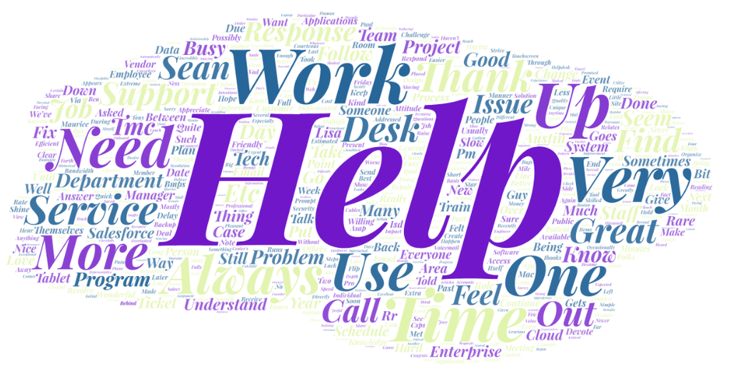

Word Cloud of All Survey Comments